# Beers and Breweries Analysis

Case Study 01 - MSDS 6306 Section 402

Luke Pierce lepierce@smu.edu

Lokesh Maganti lmaganti@smu.edu

Andrew Walch awalch@smu.edu

MJKelleher mikek@smu.edu

February 14, 2018

## Codebook

1. Raw Data
   - [Beer Names and Metrics](https://raw.githubusercontent.com/allthebits/msds6306-case-study-01/master/data/Beers.csv)
     - Variable names
       - Beer
         - The name of the beer
         - String
         - Contains non UTF-8 characters
         - No NA’s
       - Beer_ID
         - Unique Identifier of the beer
         - Integer - Range: (1 - 2692)
         - No NA’s
       - ABV
         - Alcohol by volume of the beer
         - Real Number - Range (0.001 - 0.128)
         - Contains NA’s
       - IBU
         - International Bitterness Units of the beer
         - Integer - Range (4 - 138)
         - Contains NA’s
       - Brew_ID
         - Brewery ID associated with the beer
         - Integer - Range (1 - 558)
         - No NA’s
       - Style
         - Style of the beer
         - String
         - Contains non UTF-8 characters
         - No NA’s
       - Ounces
         - Ounces of the beer
         - Real Number - Values: (8.4, 12.0, 16.0, 16.9, 19.2, 24.0, 32.0)
         - Contains NA’s
   - [Breweries By State](https://raw.githubusercontent.com/allthebits/msds6306-case-study-01/master/data/Breweries.csv)
     - Variable names
       - Brew_ID
         - Unique identifier of the brewery
         - Integer (1 - 558)
         - No NA’s
       - Brewery
         - Name of the brewery
         - String
         - Contains non UTF-8 characters
         - No NA’s
       - City
         - City where the brewery is located
         - String
         - No NA’s
       - State
         - US state where the brewery is located
         - 2 Characters
         - No NA’s
         - 51 Unique Values
2. Final Merged Data
   - Beer Names and Metrics
     - Info
       - Dataframe: beer
       - CSV name: data/tidy/beer.csv
     - Variable names
       - Beer
         - The name of the beer
         - String
         - UTF-8 characters only
         - No NA’s
       - Beer_ID
         - Unique Identifier of the beer
         - Integer - Range: (1 - 2692)
         - No NA’s
       - ABV
         - Alcohol by volume of the beer
         - Real Number - Range (0.001 - 0.128)
         - Contains NA’s
       - IBU
         - International Bitterness Units of the beer
         - Integer - Range (4 - 138)
         - Contains NA’s
       - Brew_ID
         - Brewery ID associated with the beer
         - Integer - Range (1 - 558)
         - No NA’s
       - Style
         - Style of the beer
         - String
         - UTF-8 characters only
         - No NA’s
       - Ounces
         - Ounces of the beer
         - Real Number - Values: (8.4, 12.0, 16.0, 16.9, 19.2, 24.0, 32.0)
         - No NA’s
   - Breweries By State
     - Info
       - Dataframe: brewery
       - CSV name: data/tidy/brewery.csv
     - Variable names
       - Brew_ID
         - Unique identifier of the brewery
         - Integer (1 - 558)
         - No NA’s
       - Brewery
         - Name of the brewery
         - String
         - UTF-8 characters only
         - No NA’s
       - City
         - City where the brewery is located
         - String
         - No NA’s
       - State
         - US state where the brewery is located
         - 2 Characters
         - No NA’s
         - 51 Unique Values
   - Combined Beer and Brewery Names and Metrics
     - Info
       - Dataframe: beerbrew
       - CSV name: data/tidy/beerbrew.csv
     - Variable names
       - Beer_ID
         - Integer - Range: (1 - 2692)
         - No NA’s
       - Beer
         - String - Range: (1 - 1372)
         - No NA’s
       - Style
         - String
         - No NA’s
       - Ounces
         - Real Number - Values: (8.4, 12.0, 16.0, 16.9, 19.2, 24.0, 32.0)
         - No NA’s
       - ABV
         - Real Number - Range (0.027 - 0.125)
         - No NA’s
       - IBU
         - Integer - Range (4 - 138)
         - No NA’s
       - Brew_ID
         - Integer - Range (1 - 547)
         - No NA’s
       - Brewery
         - String
         - No NA’s
       - City
         - String
         - No NA’s
       - State
         - 2 Characters - 50 Unique Values
         - No NA’s
   - Breweries by State
     - Info
       - Dataframe: breweryByState
       - CSV name: data/tidy/BreweryByState.csv
     - Variable names
       - State
         - 2 Characters - 50 Unique Values
         - No NA’s
       - Breweries
         - Integer - Range (1 - 47)
         - No NA’s
3. Data Modifications
   - Load the Beer and Breweries datasets, rename the columns, sort beer dataset
     - Define variables to be used throughout the document
     - Define base/root URL to load the data
     - Define the String URL’s for the Beer and Brewery datasets
     - Load the Beer and Brewery Datasets
   - Convert UTF-8 format character data in Dataframes for Beer and Brewery
     - Convert UTF-8 format in “beer$Name”
     - Convert UTF-8 format in “beer$Style”
     - Convert UTF-8 format in “beer$Style”
   - Modify column/variable names on the Dataframes for Beer and Brewery
     - Rename column “Name” to “Beer” in beer df
     - Rename column “Brewery_id”" to “Brew_ID” in beer df
     - Rename column “Name” to “Brewery” in brewery df
     - Arrange beer df by Brew_ID
     - Remove duplicates with all columns other than Brew_ID as criteria for removal
     - Remove row.names column
4. Tidy dataset
   - beer
   - beerbrew
     - Merge data frames
     - Sort columns
     - NA removal (all)
   - brewery
   - BreweryByState
     - Count breweries per state
     - Remove Washington DC
     - Rename column “Brewery_id”" to “Brew_ID” in beer df
     - Sort by most to least
5. Recipe for Tidy Dataset
   - Commented R script file
     - Tidy_Recipe.R

## Introduction

In all, the analysis answers 7 main questions, which are addressed below in this report.

## Answers to Data Analysis Questions

1. *How many breweries are present in each state?*

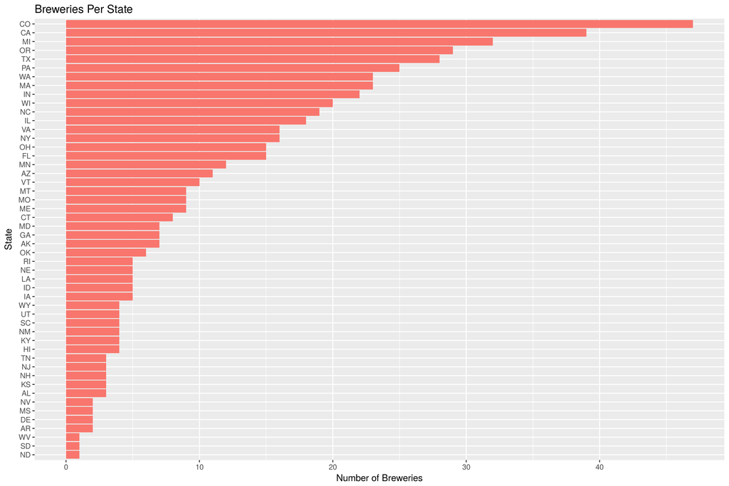

2. *After merging the Beer and Breweries datasets, what are the first and last 6 observations in the datasets?*

[figure not shown]

3. *How many **NA** values are contained in each column?*

```
There were 62 NA’s in the ABV (Alcohol By Volume) column and 998 NA’s in the IBU (International Bitterness Unit) column (see below). To ensure consistency, these rows were omitted in the ABV vs IBU analysis performed later in the study.

Beer_ID    Beer   Style  Ounces     ABV     IBU Brew_ID Brewery    City   State
   0       0       0       0      62     998       0       0       0       0
```

4. *What is the median alcohol content and international bitterness unit for each state? This also includes a bar chart of this data.*

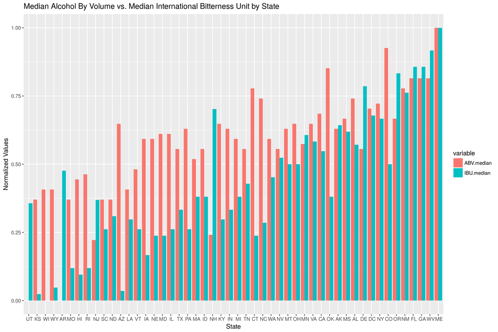

```
    The summary statistics for the ABV (Alcohol By Volume) variable are listed below:
    Min.     1st Qu.  Median   Mean     3rd Qu.  Max.
    0.02700  0.05000  0.05700  0.06007  0.06800  0.12500
```

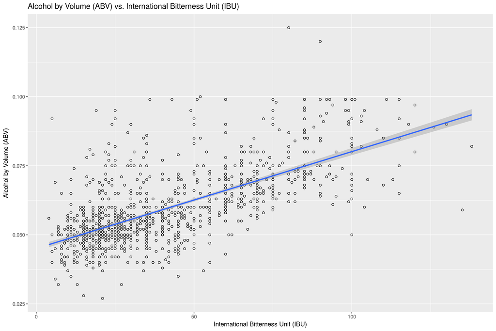

## Appendix

### Source Code

#### Required Libraries

1. deplyr - To Install: `install.packages("deplyr")`
2. ggplot2 - To Install: `install.packages("ggplot2")`
3. doBy - To Install: `install.packages("doBy")`
4. stringr - To Install: `install.packages("stringr")`
5. reshape2 - To Install: `install.packages("reshape2")`
6. gridExtra - To Install: `install.packages("gridExtra")`

#### Case Study Solution

```r
#
# NOTE:
# If you add any libraries to this file, make sure you add the library to the
# 'ENVIRONMENT' section of the file: code/00_LoadAndPrepare.R
#
library(dplyr)
library(ggplot2)
library(doBy)
library(stringr)
library(reshape2)
library(gridExtra)
library(gplots)
```

```r
#
#

#===============================================================================

## Load the Beer and Breweries datasets, rename the columns, sort beer dataset

# Define variables to be used throughout the document
# The base/root URL to load the data from
data_root_url <- "https://raw.githubusercontent.com/allthebits/msds6306-case-study-01/master/data/"

# Define the String URL's for the Beer and Brewery datasets
beer_url <- paste(data_root_url, "Beers.csv", sep="");
brewery_url <- paste(data_root_url, "Breweries.csv", sep="");

# Load the Beer and Brewery Datasets
beer <- read.csv(url(beer_url), header = TRUE, sep=",", row.names = NULL)
brewery <- read.csv(url(brewery_url), header = TRUE, sep=",", row.names = NULL)

#===============================================================================

# Convert UTF-8 format character data in Dataframes for Beer and Brewery

# Beer file

# Convert UTF-8 format in "beer$Name"
beer$Name <- str_conv(beer$Name, "UTF-8")

# Convert UTF-8 format in "beer$Style"
beer$Style <- str_conv(beer$Style, "UTF-8")

# Brewery file

# Convert UTF-8 format in "beer$Style"
brewery$Name <- str_conv(brewery$Name, "UTF-8")

# ==============================================================================

# Modify column/variable names on the Dataframes for Beer and Brewery

# in beer df rename column "Name" to "Beer"
beer <- rename(beer, Beer = Name)

# in beer df rename column "Brewery_id"" to "Brew_ID"
beer <- rename(beer, Brew_ID = Brewery_id)

# in brewery df rename column "Name" to "Brewery"
brewery <- rename(brewery, Brewery = Name)

# Arrange beer df by Brew_ID
beer <- arrange(beer, (Brew_ID))

# Remove duplicates with all columns other than Brew_ID as criteria for removal
beer <- beer[!duplicated(beer[c('Beer', 'ABV', 'IBU', 'Style', 'Ounces')]),]

# Remove row.names column
row.names(beer) <- NULL
#
#
# Case Study 01 : Question 01) Breweries per state?
# Requires the library: 'ggplot2'

# The source path MUST include the "code" directory because the context
#   when the source statement executes is within the RMarkdown file and that
# is one directory 'up' from here
source('code/01_Question_01.tidy.R')

summary(BreweryByState)
```

```
##      State      Breweries
##   AK    : 1   Min.   : 1.00
##   AL    : 1   1st Qu.: 4.00
##   AR    : 1   Median : 7.00
##   AZ    : 1   Mean   :11.14
##   CA    : 1   3rd Qu.:16.00
##   CO    : 1   Max.   :47.00
##  (Other):44
```

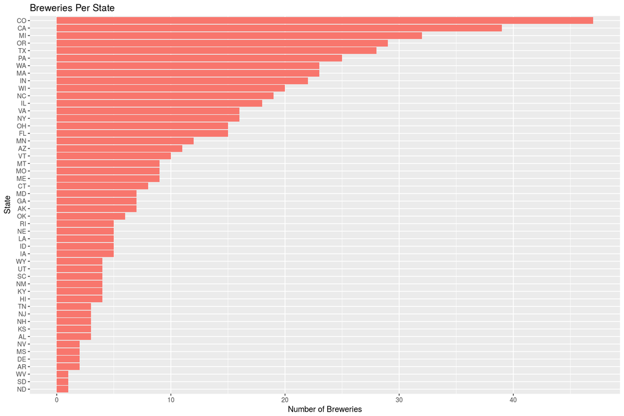

```r
q1_plot <- ggplot(BreweryByState, aes(x=reorder(State, Breweries), y=(Breweries), fill = "red")) + geom_bar(stat='identity') + coord_flip() + labs(title ="Breweries Per State", x = "State", y = "Number of Breweries") + theme(legend.position="none")

grid::grid.draw(q1_plot)
```

```r
ggsave(q1_plot, filename="tmp/q1_plot.png")
#
#
# Case Study 01 : Question 02) Merge beer and brewery data. Print first and last
#                 6 observations
# QC

source('code/02_Question_02.tidy.R')

summary(beerbrew)
```

```
##     Beer_ID           Beer              Style               Ounces
##  Min.   :   4.0   Length:2370        Length:2370        Min.   : 8.40
##  1st Qu.: 813.2   Class :character   Class :character   1st Qu.:12.00
##  Median :1457.5   Mode  :character   Mode  :character   Median :12.00
##  Mean   :1432.6                                         Mean   :13.59
##  3rd Qu.:2073.8                                         3rd Qu.:16.00
##  Max.   :2692.0                                         Max.   :32.00
##
##       ABV               IBU            Brew_ID        Brewery
##  Min.   :0.00100   Min.   :  4.00   Min.   :  1.0   Length:2370
##  1st Qu.:0.05000   1st Qu.: 21.00   1st Qu.: 94.0   Class :character
##  Median :0.05600   Median : 35.00   Median :206.0   Mode  :character
##  Mean   :0.05987   Mean   : 42.78   Mean   :232.8
##  3rd Qu.:0.06800   3rd Qu.: 64.00   3rd Qu.:367.8
##  Max.   :0.12800   Max.   :138.00   Max.   :558.0
##  NA's   :62        NA's   :998
##            City          State
##  Grand Rapids:  66    CO    : 259
##  Chicago     :  55    CA    : 180
##  Portland    :  53    MI    : 162
##  Indianapolis:  43    IN    : 139
##  Boulder     :  41    TX    : 130
##  San Diego   :  41    OR    : 114
##  (Other)     :2071   (Other):1386
```

```r
str(beerbrew)
```

```
## 'data.frame':    2370 obs. of  10 variables:
##  $ Beer_ID: int  2692 2691 2690 2689 2688 2687 2686 2685 2684 2683 ...
##  $ Beer   : chr  "Get Together" "Maggie's Leap" "Wall's End" "Pumpion" ...
##  $ Style  : chr  "American IPA" "Milk / Sweet Stout" "English Brown Ale" "Pumpkin Ale" ...
##  $ Ounces : num  16 16 16 16 16 16 16 16 16 16 ...
##  $ ABV    : num  0.045 0.049 0.048 0.06 0.06 0.056 0.08 0.125 0.077 0.042 ...
##  $ IBU    : int  50 26 19 38 25 47 68 80 25 42 ...
##  $ Brew_ID: int  1 1 1 1 1 1 2 2 2 2 ...
##  $ Brewery: chr  "NorthGate Brewing " "NorthGate Brewing " "NorthGate Brewing " "NorthGate Brewing " ...
##  $ City   : Factor w/ 384 levels "Abingdon","Abita Springs",..: 228 228 228 228 228 228 200 200 200 200 ...
##  $ State  : Factor w/ 51 levels " AK"," AL"," AR",..: 24 24 24 24 24 24 18 18 18 18 ...
```

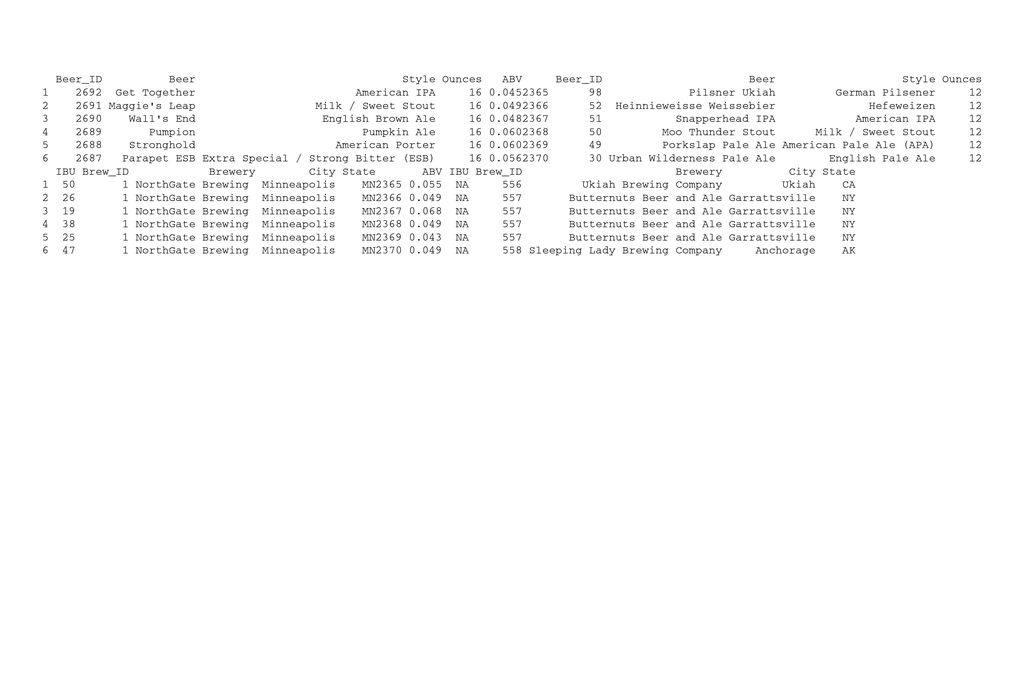

```r
# Check beerbrew

q2_out1 <- capture.output(head(beerbrew,6))
q2_out2 <- capture.output(tail(beerbrew,6))

text <- paste0(q2_out1, q2_out2)
textplot(text, valign="top")
```